# Population pyramids (assignment)

Clustering, PCA and MDS

Pedro Delicado

## Reading the 2020 population pyramids dataset.

The file `PopPyrISO.Rdata` contains the 2020 population pyramids of 189 countries and geographical regions in the world (computed using data downloaded from [United Nations, Population Division](https://population.un.org/wpp/DataQuery/)). The following sentence read these data (in the data frame `PopPyrISO`):

```r
load("PopPyrISO.Rdata")
```

The data frame `PopPyrISO` has five first columns with the ISO numeric code, English and French names, and alphanumeric ISO codes of length 2 and 3 for each country, then 21 columns for proportions of male population in different age intervals, then 21 more for females, and a last column with the total population of each country.

The following sentences define the function `plot.PopPyrISO` and use it to plot 6 randomly selected population pyramids:

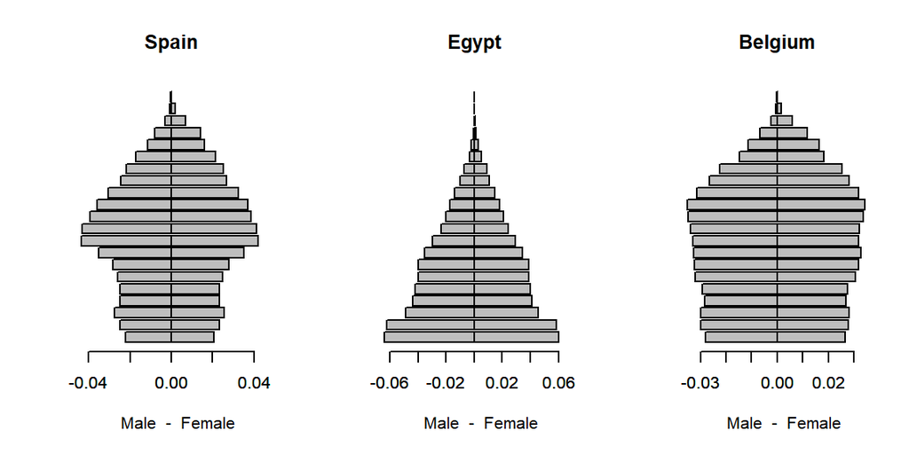

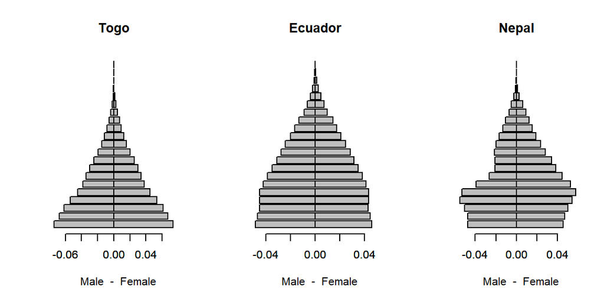

```r
plot.PopPyrISO <- function(Prop.M.F, label=NULL, col=NULL,
                           col.Male=col, col.Female=col){
  Prop.M.F <- as.numeric(Prop.M.F)
  n.ages <- length(Prop.M.F)/2
  barplot(-Prop.M.F[1:n.ages], horiz = TRUE,
          main=label, col=col.Male,
          xlab="   Male  -  Female",
          xlim=c(-1,1)*max(Prop.M.F))
  barplot(Prop.M.F[n.ages+(1:n.ages)], horiz = TRUE,
          col=col.Female, add=TRUE)
}

n <- dim(PopPyrISO)[1]
op <- par(mfrow=c(2,3))
for (j in sample(n,6))
   plot.PopPyrISO(PopPyrISO[j,(6:47)],PopPyrISO$English.short.name[j])
par(op)
```

## 1. Hierarchical custering.

Use the distance between two popultion pyramids $\mathbf{x}$ and $\mathbf{y}$ defined by the weighted $L_1$:
$$d(\mathbf{x},\mathbf{y})=\sum_{i=1}^{42} w_i|x_i - y_i|,$$
where the vector $\mathbf{w}$ of weights is the average population pyramid. The following sentences define the function `w.L1` implementing the computation of the weighted $L_1$ norm. Moreover the distance matrix corresponding to the rows of `PopPyrISO[,6:47]` is computed and stored in `D.42`:

```r
# weighted L1 norm
w.L1 <- function(pop.pyr,alpha=1){
  n<- dim(pop.pyr)[1]
  D.42 <- matrix(0,nrow=n,ncol=n)
  w.age <- apply(pop.pyr,2,mean)^alpha
  w.age <- as.numeric(w.age/sum(w.age))
  A <- as.matrix(pop.pyr)
  as.dist(
    abs( matrix(rep(A,n),nrow=n) -
         matrix(rep(as.numeric(t(A)),n),nrow=n,byrow=TRUE)
        ) %*% kronecker(diag(n),w.age)
    )
}
D.42 <- w.L1(PopPyrISO[,6:47],alpha=1)
```

### 1.a

Do a hierarchical clustering for the 2020 population pyramids dataset using the `ward.D` method, plot the dendogram, and select the number $k$ of clusters according to the average silhouette criterion, for $k$ between $2$ and $10$. Comment on the obtained results.

### 1.b

Do the silhouette plot for the chosen $k$ and comment on the obtained results.

### 1.c

Plot the average population pyramid for each cluster and comment on the obtained results.

### 1.d

Plot de world map using different colors for countries belonging to different clusters. You can use the following function:

```r
plot_world <- function(Cluster_Indicator,
                       ISO.3.code=PopPyrISO$Alpha.3.code){
  library(maps)
  # Country names in the data base 'world',
  # from library maps, of each country in
  # the data.frame used to do clusters
  country.names.world <- iso.expand(ISO.3.code)
  # assigning polygons in "world" to each country
  country.to.map <- match.map("world",country.names.world)

  ncolors <- length(unique(Cluster_Indicator))
  x <- hcl.k.star[country.to.map]
  # with a color palette
  #color <- terrain.colors(n=ncolors)
  color <- palette.colors(n = ncolors,
                          palette = "pastel 1")
  map("world", fill = TRUE, col = color[x])
  map("world", add = TRUE) # plot again borders
  legend("bottomleft",paste("Cluster",1:ncolors),
         fill=color[1:ncolors],cex=1,
         border=0,bty="o",box.col=0)
}
```

You should obtain plots similar to this one:

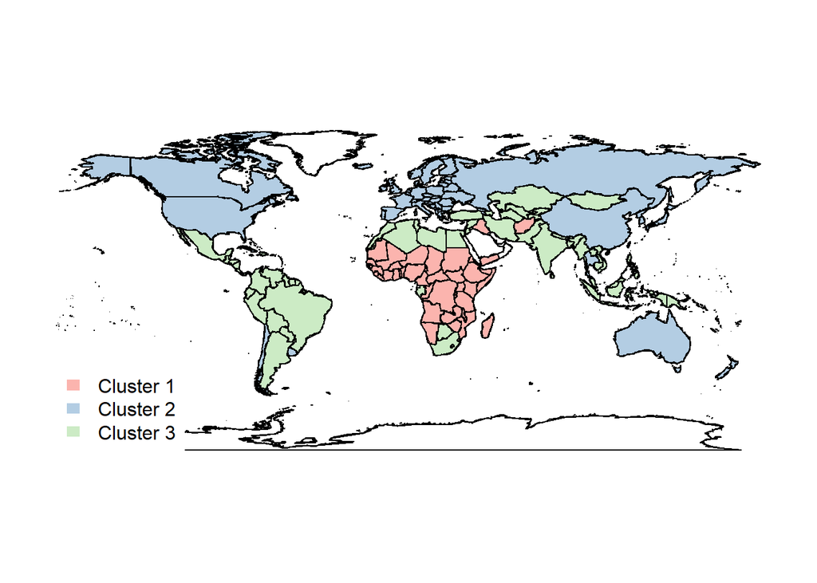

## 2. Principal Component Analysis

### 2.a

Perform PCA on the columns of the data frame `PopPyrISO` which contain the population pyramids values. Show the default biplot and indicate the cumulative percetage of explained variance for the first 10 principal components.

### 2.b

Do the following scatterplots of the PC scores,  
(PC1, PC2), (PC1, PC3), (PC1, PC4),  
labeling the points with country names.  
Looking at the scatterplot (PC1, PC2): Do you think PC1 and PC2 are independent? Do you think that it would be possible to reduce dimension to 1 using a non-linear dimensionality method?

### 2.c

Represent the first 4 principal component loadings as population pyramids using `plot.PopPyrISO` with the options `col.Male=3,col.Female=4`.

### 2.d

Do graphics of the form  
mean +/- cte.j * PC.j  
for the first 4 principal components ($j=1,2,3,4$).

### 2.e

Use the results in 2.b, 2.c and 2.d to give an interpretation of the first 2 principal components.

### 2.f

Plot the approximations of an observation (choose the row corresponding to your country) by the first $k$ PCs,
$$X_i \approx \bar{X} + \sum_{j=1}^k \psi_{ij} PC_j,$$
for $k=0,\ldots,6$.

## 3. Multidimensional Scaling

A polpulation pyramid can be considered a discrete probability distribution (its elements are non-negative and their sum is equal to 1). Consider the symmetrized Kullback-Leibler divergence as a distance between two popultion pyramids $\mathbf{x}$ and $\mathbf{y}$ defined as :
$$d_{KL}(\mathbf{x},\mathbf{y})=
\frac{1}{2}\left(
\sum_{i=1}^{42} \log\left(\frac{x_i}{y_i}\right)x_i
+
\sum_{i=1}^{42} \log\left(\frac{y_i}{x_i}\right)y_i
\right).$$
The following sentences compute the distance matrix corresponding to the rows of `PopPyrISO[,6:47]` and store it in `D.KL`:

```r
require(flexmix)
aux <- flexmix::KLdiv(t(PopPyrISO[,6:47]),method="discrete")
d.KL <- as.dist( (aux+t(aux))/2)
```

### 3.a

Perform a classical metric MDS of the data, using the `cmdscale` program, and represent the data in a space of dimension $k=2$. Plot all the eigenvalues. Indicate the value of the elements in `out$GOF`.

### 3.b

Calcualte the goodness-of-fit (in percentage) of the two-dimensional solution. Do you think $k=2$ dimension give a good representation of the data?

### 3.c

Represent the scatterplot corresponding to the first 2 dimensions obtained by MDS, labeling the points with country names.

### 3.d

Try to give an *interpretation* to each of the first 2 dimensions. To do it, plot for each dimension the population pyramid corresponding to three countries: those having scores at this dimension equal to quantiles $0.1$, $0.5$ and $0.9$.

### 3.e

Compute the fitted distances according to the two-dimensional MDS solution. Graph fitted and observed distances and assess the goodness of fit by regression. Report the coefficient of determination of this regression.

### 3.f

Now we perform non-metric MDS with the `isoMDS` program. Plot the two-dimensional solution, labeling the points with country names.

### 3.g

Give an *interpretation* to each of the first 2 dimensions (as in 3.e) and compare them to those obtained by classical metric scaling.

### 3.h

Compute the stress for a 1, 2, 3, 4, 5 and 6 dimensional solution. Plot stress as a function of the dimension. How many dimensions do you think are necessary to obtain a “good fit”?

## 4. Plotting a map with scores from PCA or MDS

### 4.a

Divide the countries into 4 groups according to their scores in the 1st PC, cutting them by the quartiles Q1, Q2 and Q3 (use the function `cut`). Then plot de world map using different colors for countries belonging to different groups.

### 4.b

Divide the countries into 4 groups according to their scores in the 1st dimension obtained by classical metric MDS, cutting them by the quartiles Q1, Q2 and Q3 (use the function `cut`). Then plot de world map using different colors for countries belonging to different groups.

### 4.c

Write your conclusion after having seen these maps and taking into account your interpretation of the results of PCA and MDS.